# Characterizing Automobiles

Author

Tatum Good

Published

March 17, 2025

# Setup

- Setup

```r
sh <- suppressPackageStartupMessages
sh(library(tidyverse))
sh(library(caret))
sh(library(fastDummies))
sh(library(class))
sh(library(ISLR)) # for the "Auto" dataframe
```

# Dataframe

- We use the `Auto` dataframe.

```r
head(Auto)
```

```
  mpg cylinders displacement horsepower weight acceleration year origin
1  18         8          307        130   3504         12.0   70      1
2  15         8          350        165   3693         11.5   70      1
3  18         8          318        150   3436         11.0   70      1
4  16         8          304        150   3433         12.0   70      1
5  17         8          302        140   3449         10.5   70      1
6  15         8          429        198   4341         10.0   70      1
                       name
1 chevrolet chevelle malibu
2         buick skylark 320
3        plymouth satellite
4             amc rebel sst
5               ford torino
6          ford galaxie 500
```

- It has the following variable names, which describe various attributes of automobiles.

```r
names(Auto)
```

```
[1] "mpg"          "cylinders"    "displacement" "horsepower"   "weight"
[6] "acceleration" "year"         "origin"       "name"
```

```r
str(Auto)
```

```
'data.frame':   392 obs. of  9 variables:
 $ mpg         : num  18 15 18 16 17 15 14 14 14 15 ...
 $ cylinders   : num  8 8 8 8 8 8 8 8 8 8 ...
 $ displacement: num  307 350 318 304 302 429 454 440 455 390 ...
 $ horsepower  : num  130 165 150 150 140 198 220 215 225 190 ...
 $ weight      : num  3504 3693 3436 3433 3449 ...
 $ acceleration: num  12 11.5 11 12 10.5 10 9 8.5 10 8.5 ...
 $ year        : num  70 70 70 70 70 70 70 70 70 70 ...
 $ origin      : num  1 1 1 1 1 1 1 1 1 1 ...
 $ name        : Factor w/ 304 levels "amc ambassador brougham",..: 49 36 231 14 161 141 54 223 241 2 ...
```

# Multiple Regression

- Run a linear regression model with `mpg` as the dependent variable and `horsepower` and `year` as features (variables).
- Compute and comment on the RMSE.

```r
model <- lm(mpg ~ horsepower + year, data = Auto)

summary(model)
```

```
Call:
lm(formula = mpg ~ horsepower + year, data = Auto)

Residuals:
     Min       1Q   Median       3Q      Max
-12.0768  -3.0783  -0.4308   2.5884  15.3153

Coefficients:
              Estimate Std. Error t value Pr(>|t|)
(Intercept) -12.739166   5.349027  -2.382   0.0177 *
horsepower   -0.131654   0.006341 -20.761   <2e-16 ***
year          0.657268   0.066262   9.919   <2e-16 ***
---
Signif. codes:  0 '***' 0.001 '**' 0.01 '*' 0.05 '.' 0.1 ' ' 1

Residual standard error: 4.388 on 389 degrees of freedom
Multiple R-squared:  0.6855,    Adjusted R-squared:  0.6839
F-statistic: 423.9 on 2 and 389 DF,  p-value: < 2.2e-16
```

```r
predictions <- predict(model, newdata = Auto)

rmse <- sqrt(mean((Auto$mpg - predictions)^2))
print(paste("RMSE:", round(rmse, 2)))
```

```
[1] "RMSE: 4.37"
```

> *Explain* This model gives us a RMSE of 4.37. Since the mpg values in our Auto dataset extend from 10 to 46m an RMSE of 4.37 could suggest a moderate level of prediction error. The model alos explains a 68.55% of variability which suggests a fairly strong relationship. Some additional observations are that Horsepower seems to have a negative impact on mpg and it looks like as horsepower increases, fuel efficiency decreases while Year has a positive impact. This makes sense as newer cars probably have a higher fuel efficiency.

# Feature Engineering

- Create 10 features based on the `name` column.
- Remove all rows with a missing value.
- Ensure only `mpg` and the engineered features remain.
- Compute and comment on the RMSE.

```r
auto <- Auto %>%
  mutate(
    power_to_weight = horsepower / weight, #how much horsepower the car has per unit of weight
    acc_to_weight = acceleration / weight, #how responsive the car is in relation to its weight
    displacement_per_cyl = displacement / cylinders, #avg engine displacement per cylinder
    hp_per_cyl = horsepower / cylinders, #power distribution across the engine
    weight_per_cyl = weight / cylinders, #how much weight each engine cylinder is carrying
    car_age = max(year) - year, #how old the car is relative to the newest car in the dataset
    efficiency_score = mpg / horsepower, #how many mpg the car gets per unit of horsepower
    weight_to_displacement = weight / displacement, #how heavy the car to its engine size
    acceleration_efficiency = mpg / acceleration, #how efficient car converts acceleration into fuel economy
    performance_index = (horsepower * acceleration) / weight #measure of horsepower and acceleration using vehicle weight
  )

#remove rows with missing values
auto <- na.omit(auto)

#only mpg and new features
final_data <- auto %>%
  select(mpg, power_to_weight, acc_to_weight, displacement_per_cyl, hp_per_cyl,
         weight_per_cyl, car_age, efficiency_score, weight_to_displacement,
         acceleration_efficiency, performance_index)

head(final_data)
```

```
  mpg power_to_weight acc_to_weight displacement_per_cyl hp_per_cyl
1  18      0.03710046   0.003424658               38.375     16.250
2  15      0.04467912   0.003113999               43.750     20.625
3  18      0.04365541   0.003201397               39.750     18.750
4  16      0.04369356   0.003495485               38.000     18.750
5  17      0.04059148   0.003044361               37.750     17.500
6  15      0.04561161   0.002303617               53.625     24.750
  weight_per_cyl car_age efficiency_score weight_to_displacement
1        438.000      12       0.13846154               11.41368
2        461.625      12       0.09090909               10.55143
3        429.500      12       0.12000000               10.80503
4        429.125      12       0.10666667               11.29276
5        431.125      12       0.12142857               11.42053
6        542.625      12       0.07575758               10.11888
  acceleration_efficiency performance_index
1                1.500000         0.4452055
2                1.304348         0.5138099
3                1.636364         0.4802095
4                1.333333         0.5243227
5                1.619048         0.4262105
6                1.500000         0.4561161
```

```r
#linear regression model using the 10features
model <- lm(mpg ~ ., data = final_data)

#predict mpg
predictions <- predict(model, newdata = final_data)

#RMSE
rmse_value <- RMSE(predictions, final_data$mpg)

print(paste("RMSE:", round(rmse_value, 2)))
```

```
[1] "RMSE: 0.66"
```

> *Explain* The RMSE for this model is 0.66 which indicates a VERY low possibility for error which means the model fits our data very well. That being said, with an error so small is it possible that the model might be overfitting to the training data which means it might perform worse on unseen data.

# Classification

- Use either of $K$-NN or Naive Bayes to predict whether an automobile is a `chevrolet` or a `honda`.
- Explain your choice of technique.
- Report on your Kappa value.

```r
#(1 = chevrolet, 0 = honda)
Auto <- Auto %>%
  mutate(brand = ifelse(grepl("chevrolet", name), "chevrolet",
                        ifelse(grepl("honda", name), "honda", NA))) %>%
  drop_na(brand)  # Remove rows that are neither

#brand column into a factor
Auto$brand <- as.factor(Auto$brand)

#only numeric features
Auto_knn <- Auto %>%
  select(-name, -origin)

#normalize
normalize <- function(x) (x - min(x)) / (max(x) - min(x))
Auto_knn[,-which(names(Auto_knn) == "brand")] <- as.data.frame(lapply(Auto_knn[,-which(names(Auto_knn) == "brand")], normalize))

#split train and test
set.seed(123)
trainIndex <- createDataPartition(Auto_knn$brand, p = 0.8, list = FALSE)
trainData <- Auto_knn[trainIndex, ]
testData <- Auto_knn[-trainIndex, ]

#knn
knn_pred <- knn(train = trainData[, -which(names(trainData) == "brand")],
                test = testData[, -which(names(testData) == "brand")],
                cl = trainData$brand, k = 5)

conf_matrix <- confusionMatrix(knn_pred, testData$brand)

print(paste("Kappa:", round(conf_matrix$overall["Kappa"], 2)))
```

```
[1] "Kappa: 0.74"
```

> *Explain* I went with KNN because it handles numerical attributes well and I want to make a binary between honda and chevrolet. KNN will also help with classifying as it will effectively group similar cars based on the attributes given to give us the best results. My model gives me a kappa of 0.74. This means the KNN model performs quite well in this classification. This model has a good level of reliability for correctly identifying the correct cars.

# Binary Classification

- Predict whether a car is a `honda`.
- Use model weights.
- Display and comment on an ROC curve.

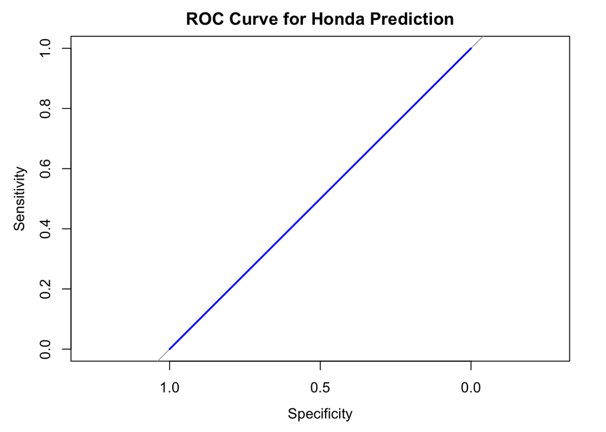

```r
library(pROC)  # For ROC curve and AUC
#Honda = 1, others = 0
Auto <- Auto %>%
  mutate(brand = ifelse(grepl("honda", name), 1, 0)) %>%
  drop_na(brand)

Auto_logit <- Auto %>%
  select(-name, -origin)

#normalize
normalize <- function(x) (x - min(x)) / (max(x) - min(x))
Auto_logit[,-which(names(Auto_logit) == "brand")] <- as.data.frame(lapply(Auto_logit[,-which(names(Auto_logit) == "brand")], normalize))

#split train and test
set.seed(123)
trainIndex <- createDataPartition(Auto_logit$brand, p = 0.8, list = FALSE)
trainData <- Auto_logit[trainIndex, ]
testData <- Auto_logit[-trainIndex, ]

#train lr model
logit_model <- glm(brand ~ ., data = trainData, family = binomial)
pred_prob <- predict(logit_model, newdata = testData, type = "response")

#ROC curve
roc_curve <- roc(testData$brand, pred_prob)
plot(roc_curve, main = "ROC Curve for Honda Prediction", col = "blue", lwd = 2)
```

```r
#AUC
auc_value <- auc(roc_curve)
print(paste("AUC:", round(auc_value, 2)))
```

```
[1] "AUC: 0.5"
```

> *Explain* The ROC shows the sensitivity vs specificity as different decision thresholds. This diagonal line indicates a random classifier which unfortunately means my model is making predictions no better than random chance. Since AUC is 0.5, this indicates that this model cannot effectively differentiate between classes. This indicates that this may be the wrong model choice and this model may be underfitting and poorly trained. This leaves a lot of area for improvement.

# Ethics

- Based on your analysis, comment on the [Clean Air Act of 1970 and Ammendments of 1977](https://www.epa.gov/clean-air-act-overview/evolution-clean-air-act)
- Discuss the civic reposibilities of data scientists for:
  - Big Data and Human-Centered Computing
  - Democratic Institutions
  - Climate Change
- Provide at least one statistical measure for each, such as a RMSE, Kappa value, or ROC curve.

> Big Data and Human-Centered Computing Data scientists working with big data and human-centered computing are responsible for ensuring that data-driven technologies are fair and inclusive. Within the Clean Air Act, big data could be used to analyze air quality trends and their impacts on various communities. Data scientists need to design systems that prioritize the privacy, security, and well-being of individuals. However, they also need to use data to inform policies and solutions related to public health and environmental protection.

```r
lm_model <- lm(mpg ~ weight + horsepower + displacement, data = Auto)
predictions <- predict(lm_model, Auto)
rmse <- sqrt(mean((predictions - Auto$mpg)^2))
print(rmse)
```

```
[1] 3.330942
```

> Democratic Institutions Data scientists have a responsibility to ensure that data used in democratic institutions is transparent, unbiased, and most of all accurate. The Clean Air Act often involves public and governmental participation in decision-making processes related to environmental protection. Data scientists need to provide clear and accessible insights through analysis. Also, they need to ensure that data collection and analysis processes serve the greater public interest.

```r
mpg_category <- ifelse(Auto$mpg > 20, "High mpg", "Low mpg")

predicted_origin <- ifelse(mpg_category == "High mpg", 1, 2)
actual_origin <- Auto$origin

# Create confusion matrix
conf_matrix <- table(Predicted = predicted_origin, Actual = actual_origin)
print(conf_matrix)
```

```
         Actual
Predicted  1  3
        1 18 13
        2 25  0
```

```r
n <- sum(conf_matrix)
po <- sum(diag(conf_matrix)) / n  #observed
pe <- sum(rowSums(conf_matrix) * colSums(conf_matrix)) / (n^2) #expected
kappa_value <- (po - pe) / (1 - pe)
print(paste("Kappa Value: ", kappa_value))
```

```
[1] "Kappa Value:  -0.43978349120433"
```

> Climate Change For data scientists working on climate change, their responsibility involves using data to understand and mitigate the impacts of climate change like air pollution or greenhouse gas emissions. This even includes their effects on the environment and public health. The Clean Air Act is a good example as it sets standards for air pollutants that contribute to climate change. Data scientists can contribute by analyzing climate data to predict future environmental conditions.

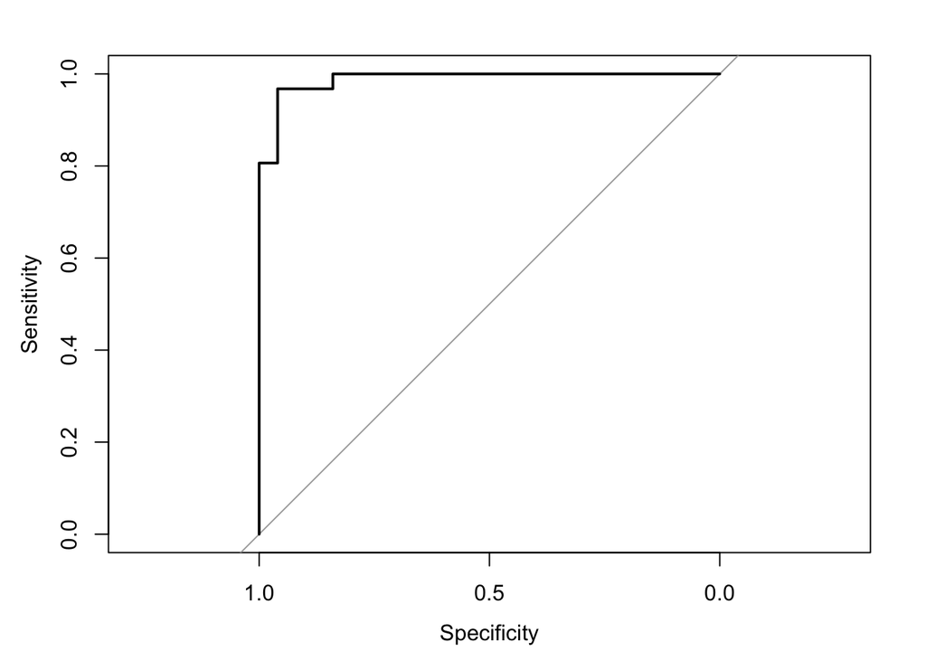

```r
#ROC curve for high vs low mpg
library(pROC)
mpg_category <- ifelse(Auto$mpg > 20, 1, 0)  # 1 = high mpg, 0 = low mpg
model <- glm(mpg_category ~ weight + horsepower + displacement, data = Auto, family = "binomial")
roc_curve <- roc(mpg_category, predict(model, Auto, type = "response"))
plot(roc_curve)
```